# Assignment 2: Population Genetics

Ethan Thibault

3/22/2018

This file is assignment two, where I will generate data using a different thinning value than what we used in class (1000 bp), run admixture, identify the differences thinning size makes, and craft a hypothesis of the demographic history of the three populations of beetles (Italy, North Carolina, and Western Australia).

## Part One

The first step is to create a new vcf file using a different thinning value. I will choose a value above and below 1000 to better elucidate the impact of thinning on K. This process needs to be done in the terminal so I will copy and paste that code below.

I ran vcf tools, calling my vcf file, thinning to 500bp, recoding it, and giving it the prefix “thin500”.

*vcftools –vcf OTAU_2018_reads2snps_DP10GP95_biallelic_MAF01_Miss0.8.vcf.recode.vcf –thin 500 –recode –out thin500*

“After filtering, kept 18137 out of a possible 133291 Sites”

I will do the same thing, but also for 1500bp thinning.

*vcftools –vcf OTAU_2018_reads2snps_DP10GP95_biallelic_MAF01_Miss0.8.vcf.recode.vcf –thin 1500 –recode –out thin1500*

“After filtering, kept 9689 out of a possible 133291 Sites”

I am also just going to run 1000bp thinning again.

*vcftools –vcf OTAU_2018_reads2snps_DP10GP95_biallelic_MAF01_Miss0.8.vcf.recode.vcf –thin 1000 –recode –out thin1000*

“After filtering, kept 11964 out of a possible 133291 Sites”

My output files that I will use PGDSpider to transform into .geno files are called:

thin500.recode.vcf

thin1000.recode.vcf

thin1500.recode.vcf

My next step is to open the bash file, and change the input file name and alter the output file name so I know which thinning parameter was used. (I will also rewrite the bash script so I have one for each file).

thin500vcf2geno.sh:

java -Xmx2G -jar /data/popgen/PGDSpider_2.0.9.0/PGDSpider2-cli.jar -inputfile ~/myresults/thin500.recode.vcf -inputformat VCF -outputfile ~/myresults/thin500.recode.vcf.geno -outputformat EIGENSOFT -spid ~/myscripts/beetle.spid

thin100vcf2geno.sh:

java -Xmx2G -jar /data/popgen/PGDSpider_2.0.9.0/PGDSpider2-cli.jar -inputfile ~/myresults/thin1000.recode.vcf -inputformat VCF -outputfile ~/myresults/thin1000.recode.vcf.geno -outputformat EIGENSOFT -spid ~/myscripts/beetle.spid

thin1500vcf2geno.sh:

java -Xmx2G -jar /data/popgen/PGDSpider_2.0.9.0/PGDSpider2-cli.jar -inputfile ~/myresults/thin1500.recode.vcf -inputformat VCF -outputfile ~/myresults/thin1500.recode.vcf.geno -outputformat EIGENSOFT -spid ~/myscripts/beetle.spid

Now I need to gain access to execute all of these bash scripts.

chmod u+x “filename”

Run bash scripts!

bash thin500vcf2geno.sh

I got this warning, not sure if it will impact my results: “Warning: Could not get charToByteConverterClass!”

bash thin1000vcf2geno.sh

bash thin1500vcf2geno.sh

Next, I will change the ADMIX.sh bash scripts to specify files as to their thinning parameter

thin500ADMIX.sh

for K in {1..10}

do

admixture -j4 –cv=10 ~/myresults/thin500.recode.vcf.geno $K | tee thin500log${K}.out

done

grep “CV” thin500log*out >thin500chooseK.txt

thin1000ADMIX.sh

for K in {1..10}

do

admixture -j4 –cv=10 ~/myresults/thin1000.recode.vcf.geno $K | tee thin1000log${K}.out

done

grep “CV” thin1000log*out >thin1000chooseK.txt

thin1500ADMIX.sh

for K in {1..10}

do

admixture -j4 –cv=10 ~/myresults/thin1500.recode.vcf.geno $K | tee thin1500log${K}.out

done

grep “CV” thin1500log*out >thin1500chooseK.txt

Change the execution rights

chmod u+x “filename”

Run the bash files!

bash “filename”

Next I will open the choose files to pick which k values to remove for each of the thinning parameters

thin500chooseK.txt

thin500log10.out:CV error (K=10): 0.72772 thin500log1.out:CV error (K=1): 0.44602 thin500log2.out:CV error (K=2): 0.43916 thin500log3.out:CV error (K=3): 0.44719 thin500log4.out:CV error (K=4): 0.48326 thin500log5.out:CV error (K=5): 0.52214 thin500log6.out:CV error (K=6): 0.55790 thin500log7.out:CV error (K=7): 0.59654 thin500log8.out:CV error (K=8): 0.63136 thin500log9.out:CV error (K=9): 0.64528

For thinning every 500bp I will extract the Q files for K values of 1, 2, 3, and 4

thin1000chooseK.txt

thin1000log10.out:CV error (K=10): 0.74078 thin1000log1.out:CV error (K=1): 0.44089 thin1000log2.out:CV error (K=2): 0.43635 thin1000log3.out:CV error (K=3): 0.44477 thin1000log4.out:CV error (K=4): 0.47987 thin1000log5.out:CV error (K=5): 0.51791 thin1000log6.out:CV error (K=6): 0.55534 thin1000log7.out:CV error (K=7): 0.58280 thin1000log8.out:CV error (K=8): 0.62599 thin1000log9.out:CV error (K=9): 0.66978

thin1500chooseK.txt

thin1500log10.out:CV error (K=10): 0.73006 thin1500log1.out:CV error (K=1): 0.44034 thin1500log2.out:CV error (K=2): 0.43440 thin1500log3.out:CV error (K=3): 0.44446 thin1500log4.out:CV error (K=4): 0.48110 thin1500log5.out:CV error (K=5): 0.51718 thin1500log6.out:CV error (K=6): 0.55927 thin1500log7.out:CV error (K=7): 0.59027 thin1500log8.out:CV error (K=8): 0.62841 thin1500log9.out:CV error (K=9): 0.66967

In another terminal on my local device, I used scp to move the Q files identified above into my ADMIXTURE folder.

scp eathibau@pbio381.uvm.edu:~/myresults/thin1000.recode.vcf.“K”.Q .

Afterwards I moved them into three new admixture folders ADMIXTUREthin500 and the other two

Next I am going to run admixture on these three outputs.

```r
# This R chunk will be for the thinning parameter of 500bp
setwd("~/Documents/UVM_2018/PBIO381/PBIO_381_Notebook")

# install.packages(c("Cairo","ggplot2","gridExtra","gtable","tidyr","devtools"),dependencies=T)
# devtools::install_github('royfrancis/pophelper')

library(pophelper)
admixfiles=list.files(path=("ADMIXTUREthin500/"),full.names=T)
admixlist=readQ(files=admixfiles,filetype="basic")

# metadata: sample id and pop from beetle.pop file
metadata=read.table("cols_data.txt",header=T)

# format metadata to a data frame and ind variables as chars. for plotting
metadata2=data.frame(sampleid=metadata[,1], population=metadata[,2])

metadata2$sampleid=as.character(metadata2$sampleid)
metadata2$population=as.character(metadata2$population)

# add in the sample id to the different Q files for plotting
if(length(unique(sapply(admixlist,nrow)))==1)
  admixlist <- lapply(admixlist,"rownames<-",metadata2$sampleid)

# four is the k = 5
head(admixlist[[4]])
```

```
##            Cluster1 Cluster2 Cluster3 Cluster4
## IT_AD4_F1_ 0.999970 0.000010    1e-05    1e-05
## IT_AD4_F2_ 0.999970 0.000010    1e-05    1e-05
## IT_AD4_F3_ 0.904393 0.095587    1e-05    1e-05
## IT_AD4_M1_ 0.999970 0.000010    1e-05    1e-05
## IT_AD4_M2_ 0.999970 0.000010    1e-05    1e-05
## IT_AD4_M3_ 0.999970 0.000010    1e-05    1e-05
```

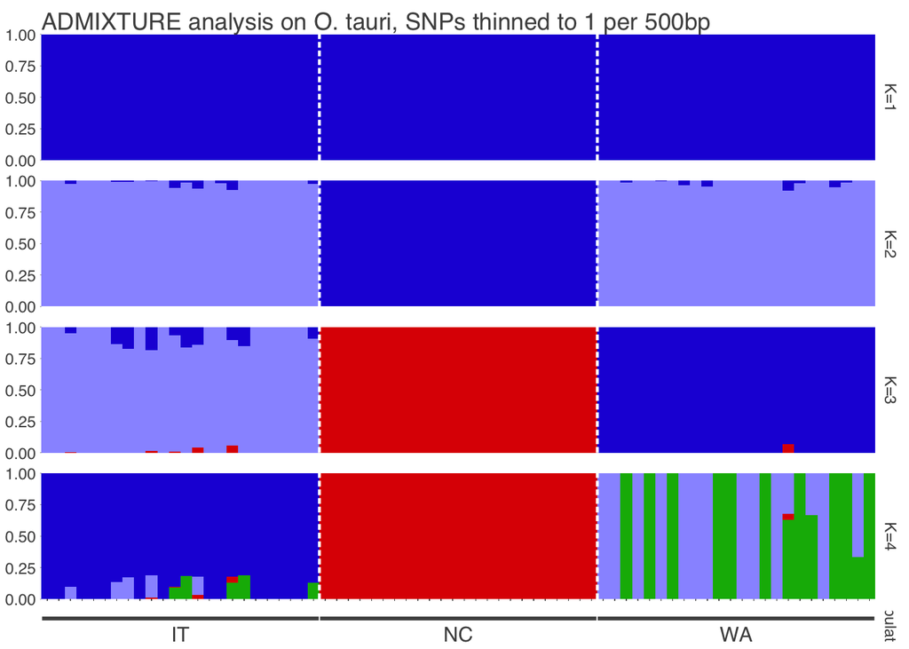

```r
pthin500 <- plotQ(admixlist[c(1,2,3,4)],
           returnplot=T,exportplot=T,quiet=T,basesize=11, imgoutput="join",
           showyaxis=T, showticks=T, panelspacer=0.4, useindlab=F, showindlab=F,
           grplab=metadata2[2], grplabsize=4, linesize=1, barsize=1, pointsize=3,
           panelratio=c(4,1), divsize = 0.75, pointcol="white", showtitle=T,
           titlelab="ADMIXTURE analysis on O. tauri, SNPs thinned to 1 per 500bp",
           splab=c("K=1","K=2","K=3","K=4"), outputfilename="thin500ADMIXTURE_Otauri",
           imgtype="pdf",height=3,width=25)

plot(pthin500$plot[[1]])
```

```r
# This R chunk will be for the thinning parameter of 1000bp

admixfiles=list.files(path=("ADMIXTUREthin1000/"),full.names=T)
admixlist=readQ(files=admixfiles,filetype="basic")

# metadata: sample id and pop from beetle.pop file
metadata=read.table("cols_data.txt",header=T)

# format metadata to a data frame and ind variables as chars. for plotting
metadata2=data.frame(sampleid=metadata[,1], population=metadata[,2])

metadata2$sampleid=as.character(metadata2$sampleid)
metadata2$population=as.character(metadata2$population)

# add in the sample id to the different Q files for plotting
if(length(unique(sapply(admixlist,nrow)))==1)
  admixlist <- lapply(admixlist,"rownames<-",metadata2$sampleid)

# four is the k = 5
head(admixlist[[4]])
```

```
##            Cluster1 Cluster2 Cluster3 Cluster4
## IT_AD4_F1_ 0.999970 0.000010    1e-05    1e-05
## IT_AD4_F2_ 0.999970 0.000010    1e-05    1e-05
## IT_AD4_F3_ 0.946039 0.053941    1e-05    1e-05
## IT_AD4_M1_ 0.999970 0.000010    1e-05    1e-05
## IT_AD4_M2_ 0.999970 0.000010    1e-05    1e-05
## IT_AD4_M3_ 0.999970 0.000010    1e-05    1e-05
```

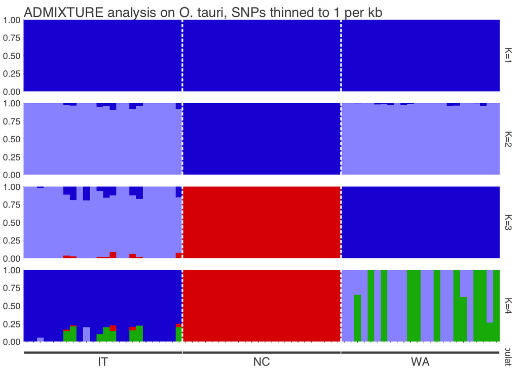

```r
pthin1000 <- plotQ(admixlist[c(1,2,3,4)],
           returnplot=T,exportplot=T,quiet=T,basesize=11, imgoutput="join",
           showyaxis=T, showticks=T, panelspacer=0.4, useindlab=F, showindlab=F,
           grplab=metadata2[2], grplabsize=4, linesize=1, barsize=1, pointsize=3,
           panelratio=c(4,1), divsize = 0.75, pointcol="white", showtitle=T,
           titlelab="ADMIXTURE analysis on O. tauri, SNPs thinned to 1 per kb",
           splab=c("K=1","K=2","K=3","K=4"), outputfilename="thin1000ADMIXTURE_Otauri",
           imgtype="pdf",height=3,width=25)

plot(pthin1000$plot[[1]])
```

```r
# This R chunk will be for the thinning parameter of 1500bp

admixfiles=list.files(path=("ADMIXTUREthin1500/"),full.names=T)
admixlist=readQ(files=admixfiles,filetype="basic")

# metadata: sample id and pop from beetle.pop file
metadata=read.table("cols_data.txt",header=T)

# format metadata to a data frame and ind variables as chars. for plotting
metadata2=data.frame(sampleid=metadata[,1], population=metadata[,2])

metadata2$sampleid=as.character(metadata2$sampleid)
metadata2$population=as.character(metadata2$population)

# add in the sample id to the different Q files for plotting
if(length(unique(sapply(admixlist,nrow)))==1)
  admixlist <- lapply(admixlist,"rownames<-",metadata2$sampleid)

# four is the k = 5
head(admixlist[[4]])
```

```
##            Cluster1 Cluster2 Cluster3 Cluster4
## IT_AD4_F1_  0.99997  0.00001    1e-05    1e-05
## IT_AD4_F2_  0.99997  0.00001    1e-05    1e-05
## IT_AD4_F3_  0.94134  0.05864    1e-05    1e-05
## IT_AD4_M1_  0.99997  0.00001    1e-05    1e-05
## IT_AD4_M2_  0.99997  0.00001    1e-05    1e-05
## IT_AD4_M3_  0.99997  0.00001    1e-05    1e-05
```

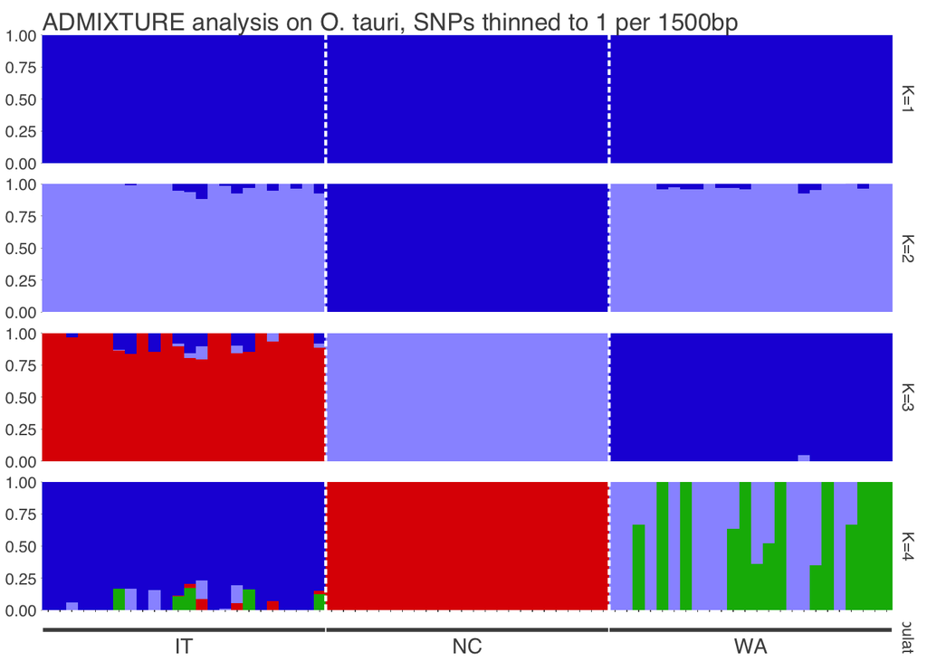

```r
pthin1500 <- plotQ(admixlist[c(1,2,3,4)],
           returnplot=T,exportplot=T,quiet=T,basesize=11, imgoutput="join",
           showyaxis=T, showticks=T, panelspacer=0.4, useindlab=F, showindlab=F,
           grplab=metadata2[2], grplabsize=4, linesize=1, barsize=1, pointsize=3,
           panelratio=c(4,1), divsize = 0.75, pointcol="white", showtitle=T,
           titlelab="ADMIXTURE analysis on O. tauri, SNPs thinned to 1 per 1500bp",
           splab=c("K=1","K=2","K=3","K=4"), outputfilename="thin1500ADMIXTURE_Otauri",
           imgtype="pdf",height=3,width=25)

plot(pthin1500$plot[[1]])
```

Here are links to the three pdf Admixture plots:

thin500

thin1000

thin1500

## Part Two

In part two I will be evaluating the nucleotide diversity between the different populations: Italy, Western Australia, and North Carolina.

Again I will be shifting to the terminal.

Here is the code to get nucleotide diversity for each of the populations (done three times one for each population):

*vcftools –vcf OTAU_2018_reads2snps_DP10GP95_biallelic_MAF01_Miss0.8.vcf.recode.vcf –keep IT.inds –site-pi –out ITpi*

Now I need to read these into R to get the mean and standard deviations:

```r
# Here I am reading in the tables
# Must read headers in as true because when I was reading them in before without the header as true, it was including the names of the columns in the actual column as row 1 and screwing up summary and mean functions

ITpi <- read.table("ITpi.sites.pi", header = TRUE)
NCpi <- read.table("NCpi.sites.pi", header = TRUE)
WApi <- read.table("WApi.sites.pi", header = TRUE)

# Run summary on these to get the mean
summary(ITpi)
```

```
##            CHROM            POS              PI
##  OTAU005778-RA:  532   Min.   :    6   Min.   :0.00000
##  OTAU012964-RA:  312   1st Qu.:  654   1st Qu.:0.08156
##  OTAU002229-RA:  290   Median : 1336   Median :0.19060
##  OTAU005777-RA:  214   Mean   : 2543   Mean   :0.22303
##  OTAU006802-RA:  187   3rd Qu.: 2700   3rd Qu.:0.38298
##  OTAU010843-RA:  177   Max.   :72391   Max.   :0.51064
##  (Other)      :66972
```

```r
 #           CHROM            POS              PI
 # OTAU005778-RA:  532   Min.   :    6   Min.   :0.00000
 # OTAU012964-RA:  312   1st Qu.:  654   1st Qu.:0.08156
 # OTAU002229-RA:  290   Median : 1336   Median :0.19060
 # OTAU005777-RA:  214   Mean   : 2543   Mean   :0.22303
 # OTAU006802-RA:  187   3rd Qu.: 2700   3rd Qu.:0.38298
 # OTAU010843-RA:  177   Max.   :72391   Max.   :0.51064
 # (Other)      :66972
summary(NCpi)
```

```
##            CHROM            POS              PI
##  OTAU005778-RA:  300   Min.   :    6   Min.   :0.0000
##  OTAU002229-RA:  244   1st Qu.:  666   1st Qu.:0.0000
##  OTAU003472-RA:  213   Median : 1384   Median :0.1560
##  OTAU000234-RA:  191   Mean   : 2530   Mean   :0.2027
##  OTAU009802-RA:  177   3rd Qu.: 2820   3rd Qu.:0.3830
##  OTAU010843-RA:  177   Max.   :72391   Max.   :0.5106
##  (Other)      :61773
```

```r
 #           CHROM            POS              PI
 # OTAU005778-RA:  300   Min.   :    6   Min.   :0.0000
 # OTAU002229-RA:  244   1st Qu.:  666   1st Qu.:0.0000
 # OTAU003472-RA:  213   Median : 1384   Median :0.1560
 # OTAU000234-RA:  191   Mean   : 2530   Mean   :0.2027
 # OTAU009802-RA:  177   3rd Qu.: 2820   3rd Qu.:0.3830
 # OTAU010843-RA:  177   Max.   :72391   Max.   :0.5106
 # (Other)      :61773
summary(WApi)
```

```
##            CHROM            POS                PI
##  OTAU002229-RA:  302   Min.   :    6.0   Min.   :0.00000
##  OTAU005778-RA:  277   1st Qu.:  659.2   1st Qu.:0.04167
##  OTAU009802-RA:  207   Median : 1365.0   Median :0.19060
##  OTAU014439-RA:  195   Mean   : 2611.6   Mean   :0.21413
##  OTAU005777-RA:  192   3rd Qu.: 2843.0   3rd Qu.:0.38298
##  OTAU000234-RA:  190   Max.   :72391.0   Max.   :0.51064
##  (Other)      :42747
```

```r
 #           CHROM            POS                PI
 # OTAU002229-RA:  302   Min.   :    6.0   Min.   :0.00000
 # OTAU005778-RA:  277   1st Qu.:  659.2   1st Qu.:0.04167
 # OTAU009802-RA:  207   Median : 1365.0   Median :0.19060
 # OTAU014439-RA:  195   Mean   : 2611.6   Mean   :0.21413
 # OTAU005777-RA:  192   3rd Qu.: 2843.0   3rd Qu.:0.38298
 # OTAU000234-RA:  190   Max.   :72391.0   Max.   :0.51064
 # (Other)      :42747

# Pull out the standard deviations
sd(ITpi$PI)
```

```
## [1] 0.168833
```

```r
# [1] 0.168833
sd(NCpi$PI)
```

```
## [1] 0.1822379
```

```r
# [1] 0.1822379
sd(WApi$PI)
```

```
## [1] 0.1767055
```

```r
# [1] 0.1767055

# The nucleotide diversity is essentially the same across the three populations
```